# TILE GRID MAP - MIREIA PERPIÑÁ VALDÉS

Para el caso de la visualización *Tile grid map* vamos a ver la mortalidad en accidentes de tráfico en cada estado de US. Para ello, vamos a usar dos datasets. Por un lado, vamos a usar el siguiente dataset para obtener los datos de accidentes: https://www.kaggle.com/datasets/sobhanmoosavi/us-accidents?select=US_Accidents_March23.csv

Y, por otro lado, vamos a usar este otro dataset que incluye las coordenadas de cada estasdo preparadas para hacer un *tile grid map* de Estados Unidos: https://www.kaggle.com/datasets/poznyakovskiy/us-tile-grid

```python
import pandas as pd

# Cargamos el dataset de accidentes
accident_data = pd.read_csv('C:/Users/Mireia/Downloads/tile_grid_map/US_Accidents_March23.csv')
# Cargamos el dataset con las coordentadas grid
grid_data = pd.read_csv("C:/Users/Mireia/Downloads/tile_grid_map/us_tile_grid.csv")
# Mostramos las primeras filas de cada uno de los datasets para ver como son los datos que contienen
grid_data.head()
```

|  | code | name | row | column |
| --- | --- | --- | --- | --- |
| 0 | AL | Alabama | 1 | 6 |
| 1 | AK | Alaska | 7 | 0 |
| 2 | AZ | Arizona | 2 | 2 |
| 3 | AR | Arkansas | 2 | 5 |
| 4 | CA | California | 3 | 0 |

```python
# Mostramos las primeras filas de cada uno de los datasets para ver como son los datos que contienen
accident_data.head()
```

|  | ID | Source | Severity | Start_Time | End_Time | Start_Lat | Start_Lng | End_Lat | End_Lng | Distance(mi) | ... | Roundabout | Station | Stop | Traffic_Calming | Traffic_Signal | Turning_Loop | Sunrise_Sunset | Civil_Twilight | Nautical_Twilight | Astronomical_Twilight |
| --- | --- | --- | --- | --- | --- | --- | --- | --- | --- | --- | --- | --- | --- | --- | --- | --- | --- | --- | --- | --- | --- |
| 0 | A-1 | Source2 | 3 | 2016-02-08 05:46:00 | 2016-02-08 11:00:00 | 39.865147 | -84.058723 | NaN | NaN | 0.01 | ... | False | False | False | False | False | False | Night | Night | Night | Night |
| 1 | A-2 | Source2 | 2 | 2016-02-08 06:07:59 | 2016-02-08 06:37:59 | 39.928059 | -82.831184 | NaN | NaN | 0.01 | ... | False | False | False | False | False | False | Night | Night | Night | Day |
| 2 | A-3 | Source2 | 2 | 2016-02-08 06:49:27 | 2016-02-08 07:19:27 | 39.063148 | -84.032608 | NaN | NaN | 0.01 | ... | False | False | False | False | True | False | Night | Night | Day | Day |
| 3 | A-4 | Source2 | 3 | 2016-02-08 07:23:34 | 2016-02-08 07:53:34 | 39.747753 | -84.205582 | NaN | NaN | 0.01 | ... | False | False | False | False | False | False | Night | Day | Day | Day |
| 4 | A-5 | Source2 | 2 | 2016-02-08 07:39:07 | 2016-02-08 08:09:07 | 39.627781 | -84.188354 | NaN | NaN | 0.01 | ... | False | False | False | False | True | False | Day | Day | Day | Day |

5 rows × 46 columns

Como el dataset de los accidentes es demasiado grande, nos vamos a quedar solo con la información correspondiente a 2023.

```python
# Nos quedamos solo con los datos para el año 2023
# Necesitamos que la columna Start_Time esté en formato fecha para poder acceder al año
accident_data['Start_Time'] = pd.to_datetime(accident_data['Start_Time'])
# Filtramos el dataset por el año 2023
accident_data_23 = accident_data[accident_data['Start_Time'].dt.year == 2023]
# Mostramos las primeras filas del dataset
accident_data_23.head()
```

|  | ID | Source | Severity | Start_Time | End_Time | Start_Lat | Start_Lng | End_Lat | End_Lng | Distance(mi) | ... | Roundabout | Station | Stop | Traffic_Calming | Traffic_Signal | Turning_Loop | Sunrise_Sunset | Civil_Twilight | Nautical_Twilight | Astronomical_Twilight |
| --- | --- | --- | --- | --- | --- | --- | --- | --- | --- | --- | --- | --- | --- | --- | --- | --- | --- | --- | --- | --- | --- |
| 3640578 | A-3650461 | Source1 | 2 | 2023-03-31 17:09:16 | 2023-03-31 18:09:49.000000000 | 45.676472 | -94.174568 | 45.666976 | -94.176184 | 0.661 | ... | False | False | False | False | False | False | Day | Day | Day | Day |
| 3640579 | A-3650462 | Source1 | 2 | 2023-02-27 20:55:00 | 2023-02-27 23:36:34.000000000 | 41.391812 | -75.467365 | 41.398370 | -75.484203 | 0.983 | ... | False | False | False | False | False | False | Night | Night | Night | Night |
| 3640580 | A-3650463 | Source1 | 2 | 2023-02-26 09:31:45 | 2023-02-26 11:58:19.000000000 | 40.850278 | -73.946140 | 40.846945 | -73.933651 | 0.692 | ... | False | False | False | False | False | False | Day | Day | Day | Day |
| 3640581 | A-3650464 | Source1 | 2 | 2023-03-21 17:46:42 | 2023-03-21 18:31:50.000000000 | 33.714992 | -84.300188 | 33.714532 | -84.266758 | 1.922 | ... | False | False | False | False | False | False | Day | Day | Day | Day |
| 3640582 | A-3650465 | Source1 | 2 | 2023-03-24 04:46:30 | 2023-03-24 09:22:00.000000000 | 33.927671 | -118.266385 | 33.929608 | -118.343065 | 4.398 | ... | False | False | False | False | False | False | Night | Night | Night | Night |

5 rows × 46 columns

Queremos ver la relación de la gravedad de los accidentes entre estados. Por lo tanto, solo necesitamos las columnas *ID*, *State* y *Severity*:

```python
accident_data_23 = accident_data_23[['ID', 'State', 'Severity']]
accident_data_23.head()
```

[output not shown]

En la visualización, vamos a filtrar por el nivel de gravedad del accidente. Por ejemplo, nos quedamos con los accidentes mortales:

```python
accident_data_23 = accident_data_23[accident_data_23['Severity']==4]
# Ahora agrupamos por estado para ver cuantos accidentes mortales hay por cada uno
accident_state = accident_data_23.groupby('State').size().reset_index(name='Num_Accidentes_Estado')
accident_state.head()
```

|  | State | Num_Accidentes_Estado |
| --- | --- | --- |
| 0 | AL | 31 |
| 1 | AR | 157 |
| 2 | AZ | 129 |
| 3 | CA | 234 |
| 4 | CO | 469 |

Ahora que tenemos el dataset que nos interesa, lo unimos al dataset que teníamos con las coordenadas grid:

```python
# Notamos que el campo State se corresponde con el campo code: hacemos esa unión
final_data = pd.merge(accident_state,grid_data, left_on = 'State', right_on = 'code')
final_data.head()
```

|  | State | Num_Accidentes_Estado | code | name | row | column |
| --- | --- | --- | --- | --- | --- | --- |
| 0 | AL | 31 | AL | Alabama | 1 | 6 |
| 1 | AR | 157 | AR | Arkansas | 2 | 5 |
| 2 | AZ | 129 | AZ | Arizona | 2 | 2 |
| 3 | CA | 234 | CA | California | 3 | 0 |
| 4 | CO | 469 | CO | Colorado | 3 | 3 |

```python
# Tenemos la columna State y code repetida, nos quedamos solo con State
final_data = final_data[['State','name','Num_Accidentes_Estado','row','column']]
# Ya tenemos el dataset con la información que nos interesa
final_data.head()
```

|  | State | name | Num_Accidentes_Estado | row | column |
| --- | --- | --- | --- | --- | --- |
| 0 | AL | Alabama | 31 | 1 | 6 |
| 1 | AR | Arkansas | 157 | 2 | 5 |
| 2 | AZ | Arizona | 129 | 2 | 2 |
| 3 | CA | California | 234 | 3 | 0 |
| 4 | CO | Colorado | 469 | 3 | 3 |

Pasemos entonces a crear la visualización *tile grid map* de los accidentes mortales en US en el año 2023:

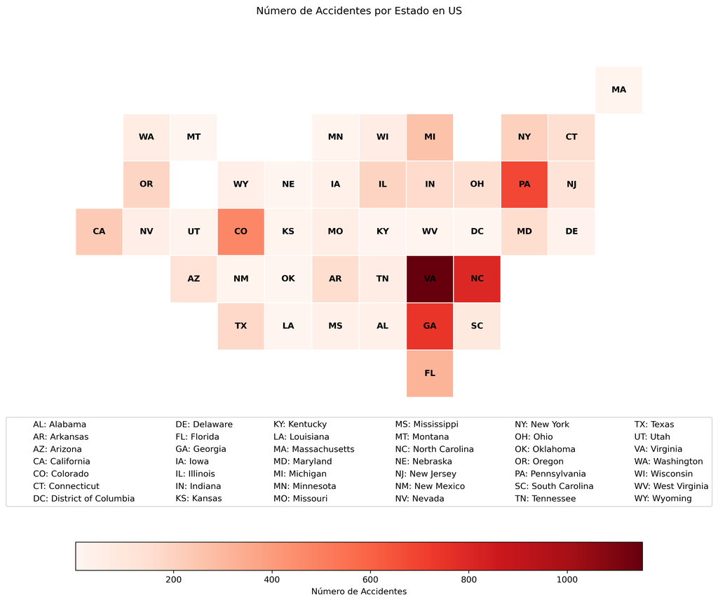

```python
import matplotlib.pyplot as plt
import matplotlib.patches as patches
import matplotlib.cm as cm
import matplotlib.colors as mcolors

# Creamos la figura
fig, axs = plt.subplots(1, figsize=(12, 6), dpi=300)
plt.xlim(0, 12)
plt.ylim(0, 8)
plt.axis('off')
axs.set_aspect('equal')

# Normalizamos los datos para aplicar la paleta de colores colormap
min_accidents = final_data['Num_Accidentes_Estado'].min()
max_accidents = final_data['Num_Accidentes_Estado'].max()
norm = mcolors.Normalize(vmin=min_accidents, vmax=max_accidents)
# Vamos a usar una paleta con tonos rojos
cmap_type = 'Reds'
cmap = cm.get_cmap(cmap_type)

# Hacemos el tile grid map
for _, state in final_data.iterrows():
    accident_color = cmap(norm(state['Num_Accidentes_Estado'])) if not pd.isna(state['Num_Accidentes_Estado']) else 'lightgrey'

    # Creamos la cuadricula de cada estado
    box = patches.Rectangle((state['column'], state['row']), 1, 1, linewidth=1, edgecolor='white', facecolor=accident_color)

    # Añadir la abreviatura de los estados en la cuadricula
    plt.text(state['column'] + 0.5, state['row'] + 0.5, state['State'],
             horizontalalignment='center', verticalalignment='center',
             color='black', weight='bold')
    axs.add_patch(box)

# Necesitamos leyendas para entender los colores y las abreviaturas de los estados
# Añadimos una barra de color con el número de accidentes que representa cada color
sm = cm.ScalarMappable(cmap=cmap_type, norm=norm)
fig.colorbar(sm, orientation='horizontal', fraction=0.046, pad=0.04, label='Número de Accidentes')

# Añadimos una leyenda para relacionar cada abreviatura con su estado y así facilitar la comprensión del gráfico
state_names_legend = [patches.Patch(color='none', label=f"{row['State']}: {row['name']}") for _, row in final_data.iterrows()]
plt.legend(handles=state_names_legend, loc='lower center', ncol=6, bbox_to_anchor=(0.5, -0.30))

# Añadimos el título de la visualización y la mostramos
plt.title('Número de Accidentes por Estado en US')
plt.subplots_adjust(top=10)
plt.show()
```

Para hacer un *tile grid map* en Python he consultado: https://www.kaggle.com/code/poznyakovskiy/us-tile-grid-map